# Data Science Capstone

Samuel Quiroga

## Milestone Report

This is the first Milestone Report for the Data Science Specialization Capstone with John’s Hopkins University. The purpose of this document is to highlight the getting and cleaning of the data, and perform some exploratory data analysis.

### Task 1 : Getting and Cleaning Data

The goal of this task is to get familiar with the databases and do the necessary cleaning. The following tasts will be accomplished:

1. Tokenization : identifying appropriate tokens such as words, punctuation, and numbers. Writing a function that takes a file as input and returns a tokenized version of it
- This task will be performed on **Task 2: Exploratory Data Analysis** using `quanteda` package.
2. Profanity filtering : removing profanity and other words I do not want to predict.
- This task will be performed manually using a pre-defined list of profanity words obtained from the web.

#### Download data

Here, I create `data` folder and download data set using the `url` provided. This step takes some time, so here I run it only the first time. For more information see the Appendix section of this document.

#### Read the data

First take a look at the first few lines of the data. Here we’ll look at the Twitter data set, using the `readLines()` function while a connection is open:

```r
enTwitter <- "./data/final/en_US/en_US.twitter.txt"
con <- file(enTwitter, "r")
readLines(con, 3) ## Read the first three lines of text
```

```
## [1] "How are you? Btw thanks for the RT. You gonna be in DC anytime soon? Love to see you. Been way, way too long."
## [2] "When you meet someone special... you'll know. Your heart will beat more rapidly and you'll smile for no reason."
## [3] "they've decided its more fun if I don't."
```

We can see each line contains a Twitter message. The same can be said of the News and Blogs data sets: each lines contains a paragraph or sentence.

Close connection

```r
close(con) ## It's important to close the connection when  done
```

#### Loading the Data:

I create function called `my.sample()` that samples each lines of the data sets based on a biased coin flip (using `rbinom` function). The function will read the lines using a file connection and will keep each line based on the result of a “coin flip”. The probability of the “coin flip”, can be set with the `prob` argument inside the function `my.sample()`, based on how much or how little of the data we want to sample, I can assign the appropiate probability argument `prob`. As each line is read, the following cleaning is performed:

- The words are set to lower case to make it easier to remove the profanity language later on.
- The word encoding is set to “UTF-8”.
- The output of the function is a list, which makes it easier and faster to load and manipulate later on.

Run the function `my.sample()` on all corpus data sets using a specified percentage probability of total samples, this can be done in the `prob` argument of the function. For more information on the function, see the Appendix section of this document. In this case I will sample 6%, 50% and 8% of the Twitter, News, and Blogs data sets respectively.

After sampling each of the data sets, we can observe the memory size each object is taking up in the R environment

```
## blogsText
```

```
## 28.4 Mb
```

```
## newsText
```

```
## 14.3 Mb
```

```
## twitterText
```

```
## 35.7 Mb
```

#### Remove profanity language

First I get list of profanity words from the web. In this case I am using a base list of profanity words blacklisted by Google; see https://www.freewebheaders.com/full-list-of-bad-words-banned-by-google/ and the Appendix section of this document for more information.

Check out the size of the profainity table:

```r
dim(profanity.table)
```

```
## [1] 75  1
```

Remove any lines that contain profanity words `profanity.words` :

```r
twitterText<- twitterText[lapply(twitterText,function(x){str_detect(x,profanity.words)}) == F]
newsText<- newsText[lapply(newsText,function(x){str_detect(x,profanity.words)}) == F]
blogsText<- blogsText[lapply(blogsText,function(x){str_detect(x,profanity.words)}) == F]
```

### Task 2 : Exploratory data analysis

1. Perform a thorough exploratory analysis of the data, understanding the distribution of words and relationship between the words in the corpora.
2. Understand frequencies of words and word pairs - build figures and tables to understand variation in the frequencies of words and word pairs in the data.

#### Creating Corpus

Before we create the corpus, I convert the lists of texts into character vectors so that its more efficient to convert it to a corpus than using a data-frame. Using the Quanteda package, I then create a corpus from the text data and assign a document variable name to each, one for each type of file: news, Twitter, and blogs:

```r
twitterText <- corpus(twitterText,docnames="Twitter")
newsText <- corpus(newsText,docnames="News")
blogsText <- corpus(blogsText,docnames="Blogs")
```

I then merge each corpus into one and take a look at the summary of the corpus. We can see that even a small sample size between 6-8%, the Twitter and Blogs texts contain between 2 and 3 million tokens!

```r
allCorpus <- twitterText + blogsText + newsText
summary(allCorpus)
```

```
## Corpus consisting of 3 documents:
##
##     Text Types  Tokens Sentences
##  Twitter 76912 2089851     72084
##    Blogs 90570 3085550     21664
##     News 67937 1472365      2682
##
## Source: Combination of corpuses twitterText + blogsText and newsText
## Created: Mon Jan 07 15:35:38 2019
## Notes:
```

Notice that we may not be counting sentences correctly because we set all words to be lower-case in the steps above.

#### Tokenization

This produces an intermediate object, consisting of a list of tokens in the form of character vectors, where each element of the list corresponds to an input document. For this report, I’ll remove punctuation, numbers and symbols (including Twitter symbols) to start. Take a look at the first 20 tokens from the “Blogs” text file.

```
##  [1] "in"         "the"        "years"      "thereafter" "most"
##  [6] "of"         "the"        "oil"        "fields"     "and"
## [11] "platforms"  "were"       "named"      "after"      "pagan"
## [16] "gods"       "we"         "love"       "you"        "mr"
```

#### Extracting features

From the tokens object I construct a document-feature matrix. In this case I remove stopwords: look at the first 10 samples

```r
my_Dfm <- dfm(allTokens,remove = stopwords('en'))
my_Dfm[,1:10]
```

```
## Document-feature matrix of: 3 documents, 10 features (0.0% sparse).
## 3 x 10 sparse Matrix of class "dfm"
##          features
## docs      btw thanks gonna  dc anytime soon love  see  way long
##   Twitter 177   5480  1174 237     104 1114 6140 3872 2062 1046
##   Blogs    25    530   116  70      39  722 3331 3579 3376 1717
##   News      1     83    20   7      16  205  378  795 1018  662
```

#### Some words are more frequent than others - what are the distributions of word frequencies?

To access the counts and document frequencies of the most commonly occuring features, we use `textstat_frequency()` from the Quanteda package. Here is a list of the top ten features within each document, with their corresponding frequency count:

|  | feature | frequency | rank | docfreq | group |
| --- | --- | --- | --- | --- | --- |
| 1 | one | 8865 | 1 | 1 | Blogs |
| 2 | just | 7232 | 2 | 1 | Blogs |
| 3 | can | 7195 | 3 | 1 | Blogs |
| 4 | like | 6980 | 4 | 1 | Blogs |
| 5 | time | 6520 | 5 | 1 | Blogs |
| 6 | get | 5108 | 6 | 1 | Blogs |
| 7 | know | 4405 | 7 | 1 | Blogs |
| 8 | now | 4382 | 8 | 1 | Blogs |
| 9 | people | 4272 | 9 | 1 | Blogs |
| 10 | also | 4016 | 10 | 1 | Blogs |

[output cut: 20 more lines]

For each type of document (News, Blogs, Twitter), here are the number of features that occur only once:

| group | n |
| --- | --- |
| Blogs | 44377 |
| News | 31277 |
| Twitter | 40650 |

#### What are the frequencies of 2-grams and 3-grams in the dataset?

Now lets see what the frequeny count of 2-grams and 3-grams are in the dataset. I will only look at the top 10 features.

For 2-grams:

|  | feature | frequency | rank | docfreq | group |
| --- | --- | --- | --- | --- | --- |
| 1 | of_the | 13528 | 1 | 1 | Blogs |
| 2 | in_the | 11265 | 2 | 1 | Blogs |
| 3 | to_the | 6313 | 3 | 1 | Blogs |
| 4 | on_the | 5572 | 4 | 1 | Blogs |
| 5 | to_be | 4869 | 5 | 1 | Blogs |
| 6 | and_the | 4177 | 6 | 1 | Blogs |
| 7 | for_the | 4135 | 7 | 1 | Blogs |
| 8 | i_was | 3632 | 8 | 1 | Blogs |
| 9 | it_is | 3505 | 9 | 1 | Blogs |
| 10 | and_i | 3484 | 10 | 1 | Blogs |

[output cut: 20 more lines]

For 3-grams:

|  | feature | frequency | rank | docfreq | group |
| --- | --- | --- | --- | --- | --- |
| 1 | one_of_the | 1069 | 1 | 1 | Blogs |
| 2 | a_lot_of | 959 | 2 | 1 | Blogs |
| 3 | the_end_of | 531 | 3 | 1 | Blogs |
| 4 | it_was_a | 488 | 4 | 1 | Blogs |
| 5 | some_of_the | 488 | 5 | 1 | Blogs |
| 6 | be_able_to | 484 | 6 | 1 | Blogs |
| 7 | as_well_as | 469 | 7 | 1 | Blogs |
| 8 | a_couple_of | 462 | 8 | 1 | Blogs |
| 9 | to_be_a | 456 | 9 | 1 | Blogs |
| 10 | out_of_the | 454 | 10 | 1 | Blogs |

[output cut: 20 more lines]

#### How many unique words do you need in a frequency sorted dictionary to cover 50% of all word instances in the language? 90%?

First, I convert the frequency count to a proportion within documents, using `dfm_weight(scheme = "prop")`.

```r
prop_myDfm <- dfm_weight(my_Dfm,scheme="prop")
statPropDF <-  textstat_frequency(prop_myDfm)
```

Then, convert the result to a dataframe. The dataframe will have the proportion for each document type (Blogs, Twitter, News).

```r
my_propDf <- convert(prop_myDfm,to = "data.frame")
names <- my_propDf$document # get names
my_propDft <- as.data.frame(t(my_propDf[,-1])) # transpose and convert to dataframe
colnames(my_propDft) <- names # assign col names
my_propDf.new <- rownames_to_column(my_propDft,var = "Character")
datatable(head(my_propDf.new,10)) %>% formatPercentage(columns = c("Twitter","Blogs","News"),digits = 5)
```

|  | Character | Twitter | Blogs | News |
| --- | --- | --- | --- | --- |
| 1 | btw | 0.000186429609656422 | 1.84276361470614e-05 | 1.40930819879138e-06 |
| 2 | thanks | 0.00577194497693329 | 0.000390665886317701 | 0.000116972580499684 |
| 3 | gonna | 0.00123654441659118 | 8.55042317223648e-05 | 2.81861639758275e-05 |
| 4 | dc | 0.000249626087506056 | 5.15973812117719e-05 | 9.86515739153964e-06 |
| 5 | anytime | 0.000109540561606033 | 2.87471123894158e-05 | 2.2548931180662e-05 |
| 6 | soon | 0.00117334793874155 | 0.000532190131927133 | 0.000288908180752232 |
| 7 | love | 0.00646710623327927 | 0.00245529824023446 | 0.000532718499143141 |
| 8 | see | 0.00407827937056308 | 0.00263810039081331 | 0.00112040001803914 |
| 9 | way | 0.00217185228876577 | 0.00248846798529917 | 0.00143467574636962 |
| 10 | long | 0.0011017252638453 | 0.00126561005058018 | 0.000932962027599892 |

Get the number of unique words to cover **50%** of all the word instances. Here we calculate cumulative frequencies for each character grouped by document type

| Document | count |
| --- | --- |
| Blogs | 973 |
| News | 1217 |
| Twitter | 555 |

Get the number of unique words to cover **90%** of all the word instances

| Document | count |
| --- | --- |
| Blogs | 15357 |
| News | 15891 |
| Twitter | 11656 |

Therefore, 90% of all word instances contain between 11,000 and 16,000 words. This will be helpful when modelling as the size of the training data set can be greatly reduced

Finally, I plot frequencies counts by document type:

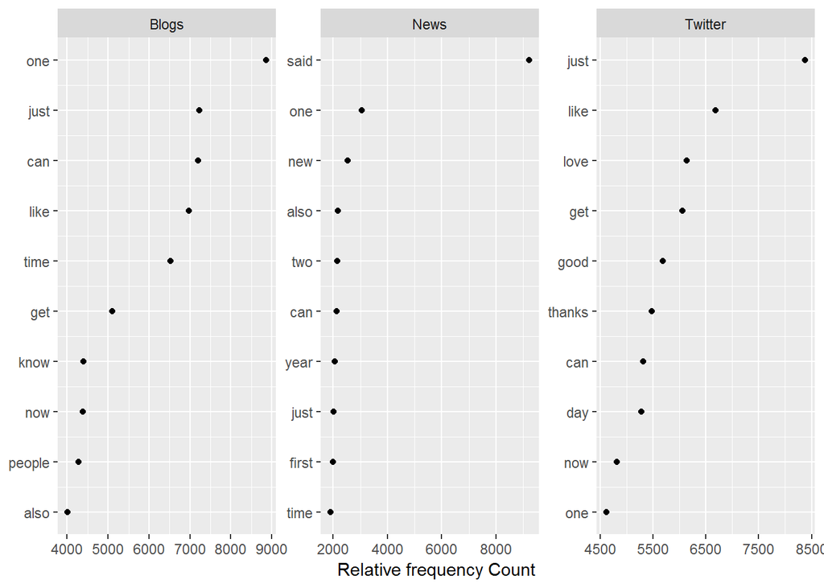

## Task 3 : Modelling

Tasks to accomplish

1. Build basic n-gram model : using the exploratory analysis performed, build a basic n-gram model for predicting the next word based on the previous 1, 2, or 3 words.
2. Build a model to handle unseen n-grams : in some cases people will want to type a combination of words that does not appear in the corpora. Build a model to handle cases where a particular n-gram isn’t observed.

For these tasks, I have considered doing the following:

- Store the n-gram model using Markov Chains
- Remove words from the corpora that occur only once
- Only use the unique words that cover 90% of all instances
- I will use up to 4 parameters (4-grams) for this model
- I will be computing the maximum likeihood estimator for each n-gram probability
- I will most likely use Kat’z Back-Off to estimate the probability of unobserved n-grams

Where there is room for improvement:

- I’m not quite sure how to evaluate whether the model is accurate or not
- I’m not quite sure how to smooth probabilities
- How to implement back-off models to account for un-observed n-grams

## Appendix

The following summarizes some of the steps involved during the analysis of the Milestone Report

#### Download data

```r
if (!file.exists("data")) {dir.create("data")}
url <- "https://d396qusza40orc.cloudfront.net/dsscapstone/dataset/Coursera-SwiftKey.zip"
dest <- "./data/dataset.zip"
download.file(url,dest)
unzip(dest,exdir = "./data")
```

#### Function to sample text files based on a predefined probability

```r
my.sample <- function(filepath,prob){
        # get length
        con0 <- file(filepath,"r")
        l <- as.numeric(length(readLines(con0,warn = F)))
        close(con0)
        # start new connection and empty list
        con1 <- file(filepath,"r")
        x <- list()
        # loop through each line
        for(i in 1:l){
                b <- rbinom(1,1,prob)
                if(b == 1){
                        t <- readLines(con1,1,warn = F,encoding = "UTF-8")
                        x[i] <- tolower(t) # for a list
                } else{
                        NULL
                }
        }
        close(con1) # close connection
        names(x) <- seq_along(x)
        x[sapply(x, is.null)] <- NULL # remove null data
        x
}
```

#### How to Remove Profanity

Download list of words:

```r
profanity.url <- "https://www.freewebheaders.com/download/files/full-list-of-bad-words_csv-file_2018_07_30.zip" # full list : used
profanity.dest <- "./data/profanity_words.zip"
download.file(profanity.url,profanity.dest);unzip(profanity.dest,exdir = "./data")
```

Read list of profanity words into the R environment.

```r
profanity.table <- read.csv("./data/full-list-of-bad-words_csv-file_2018_07_30.csv",header = FALSE,sep = ";",stringsAsFactors = FALSE)
```

Clean the data:

Remove any lines that contain profanity.

```r
twitterText<- twitterText[lapply(twitterText,function(x){str_detect(x,profanity.words)}) == F]
newsText<- newsText[lapply(newsText,function(x){str_detect(x,profanity.words)}) == F]
blogsText<- blogsText[lapply(blogsText,function(x){str_detect(x,profanity.words)}) == F]
```

#### Getting number of unique words that cover specific percentage

Here is an example of how to get the number of unique words to cover **50%** of all the word instances. Here we calculate cumulative frequencies for each character grouped by document type

```r
my_propDf.new %>%
        gather("Twitter","Blogs","News",key="Document",value = "Frequency") %>%
        arrange(Document,desc(Frequency)) %>%
        group_by(Document) %>%
        mutate(Cum.Freq=cumsum(Frequency)) %>%
        filter(Cum.Freq<=0.5) %>%
        summarise(count=n())
```